# Davies Rotation OrbFav Reuptake

- Set your working directory; if your files are in folders, you have to specify the command to enter the folder with a slash
- Load the proper packages

```r
setwd("/Users/mariaingersoll/Desktop/BU Research/Davies-Gilmore")
library("DESeq2")
library("ggplot2")
```

- Read in counts using read.table, of pre-filtered count data. The function read.table reads a file in table format and creates a data frame from it (cases corresponding to lines and variables to fields in the file)

```r
countData <- read.table("fav_uptake_cleaned_BM3.txt")
head(countData)
```

```
##            BR.A BR.B BR.C DR.A DR.C DR.D
## ofav100240    0    0    5    5    0    8
## ofav105450    0    0   12    2    3    1
## ofav111453    0    0    1    3    0   14
## ofav111699    0    0    3    2    0   13
## ofav112042    0    0    5    8    0    5
## ofav112798    0    0    3    3    0   12
```

- All data were previously filtered for a base mean of 3
- Now determine the length of the data file

```r
length(countData[,1])
```

```
## [1] 8573
```

- Get and plot total counts data for each reinfection experiment

```r
totalCounts=colSums(countData)
totalCounts
```

```
##    BR.A    BR.B    BR.C    DR.A    DR.C    DR.D
##   70876   48727  940256  992205   42187 1184224
```

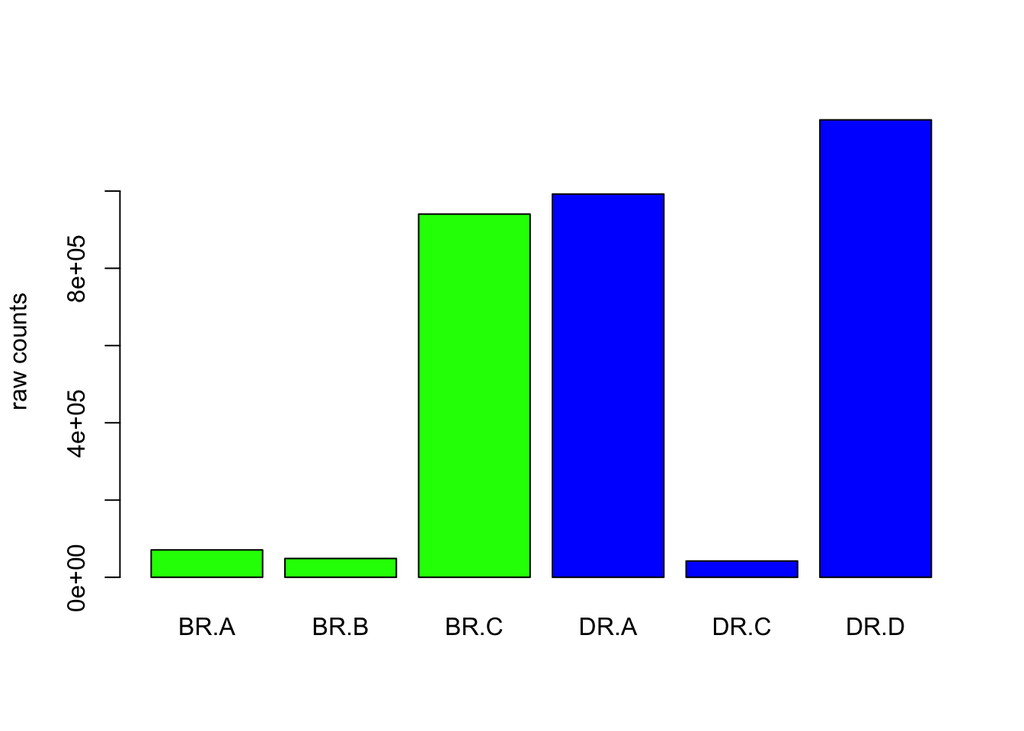

```r
barplot(totalCounts, col=c("green",  "green", "green", "blue" , "blue" , "blue"), ylab="raw counts")
```

```r
min(totalCounts)
```

```
## [1] 42187
```

```r
max(totalCounts)
```

```
## [1] 1184224
```

```r
treat=c( "B", "B", "B", "D", "D", "D")
g=data.frame(treat)
g
```

```
##   treat
## 1     B
## 2     B
## 3     B
## 4     D
## 5     D
## 6     D
```

```r
colData<- g
colData
```

```
##   treat
## 1     B
## 2     B
## 3     B
## 4     D
## 5     D
## 6     D
```

- run DESeqDataSetFromMatrix and name it dds with countData for matrix input, colData for columns, and “treat” to dictate how the counts for each gene depend on the variables in colData
- then run DESeq on dds

```r
dds<-DESeqDataSetFromMatrix(countData=countData, colData=colData, design=~treat)
dds<-DESeq(dds)
```

```r
head(dds)
```

```
## class: DESeqDataSet
## dim: 6 6
## metadata(1): version
## assays(4): counts mu H cooks
## rownames(6): ofav100240 ofav105450 ... ofav112042 ofav112798
## rowData names(22): baseMean baseVar ... deviance maxCooks
## colnames(6): BR.A BR.B ... DR.C DR.D
## colData names(2): treat sizeFactor
```

```r
res<- results(dds)
```

- The above code gives the log2 fold change (MLE): treat D vs B
- this means that pos log2FC values indicate D is upregulated compared to B
- The name provided in the second element (B) is the baseline

-Next look at the dispersions plot, which basically just tells you the spread of your data

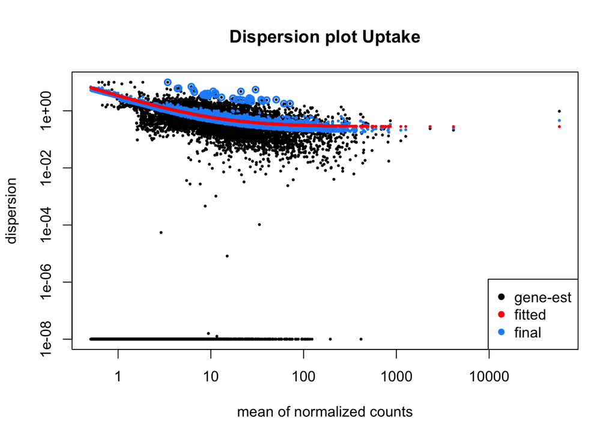

```r
plotDispEsts(dds, main="Dispersion plot Uptake")
```

- Now we are going to retrieve the rlog data, which will give us better transformation when size factors vary across samples
- regularized log transformation, transforms count data to log2 scale to minimize differences between samples for rows with small counts

```r
rld <- rlogTransformation(dds, blind=TRUE)
head(assay(rld))
```

```
##                   BR.A        BR.B        BR.C        DR.A        DR.C
## ofav100240 -0.18317292  0.15308730  0.04448964  0.01382183  0.05193387
## ofav105450 -0.07668887  0.41575392  1.05261483 -0.63972074  2.88779009
## ofav111453 -0.35792397 -0.03161843 -0.74308184 -0.39909254 -0.12977730
## ofav111699 -0.30100842  0.02764607 -0.32044366 -0.50483852 -0.07121941
## ofav112042 -0.17887173  0.16119687  0.05041091  0.30434686  0.05889781
## ofav112798 -0.26495065  0.06508583 -0.28610076 -0.31118027 -0.03419538
##                   DR.D
## ofav100240  0.17668962
## ofav105450 -1.18835871
## ofav111453  0.40725858
## ofav111699  0.39991365
## ofav112042 -0.08104409
## ofav112798  0.36910147
```

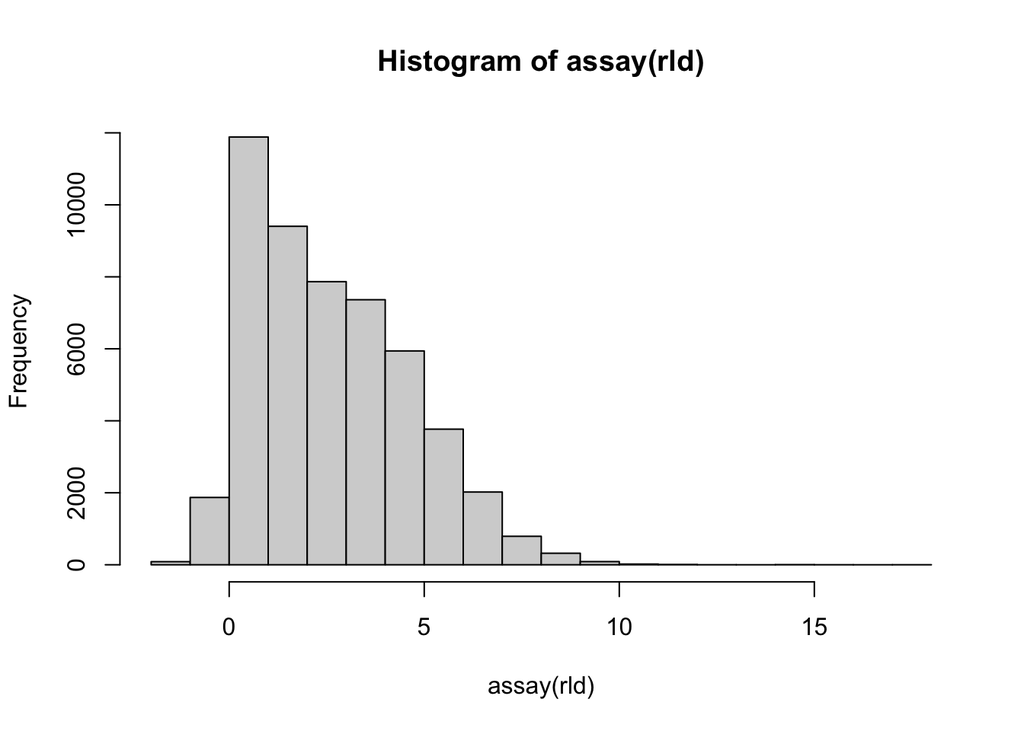

```r
hist(assay(rld))
```

- The assay function allows you to access the matrix-like data, so that you can view it bc head(rld) gives you just a summary
- The histogram above displays the frequency of each binned rld count value
- Load the library RColorBrewer

```r
library(RColorBrewer)
```

- Making a sample distance heatmap
- as.matrix attempts to turn its argument into a matrix
- dist computes and returns the distance matrix computed using the specified distance measure to compute distances between the rows of a data matrix (assay(rld))
- Create a sample heatmap of the relatedness based on the count distance/difference between samples

```r
sampleDists <- as.matrix(dist(t(assay(rld))))
library(gplots)
```

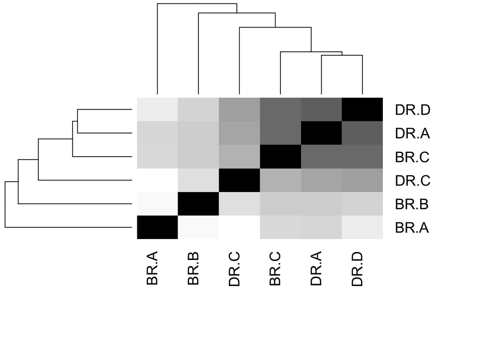

```r
heatmap.2(as.matrix(sampleDists), key=F, trace="none",
          col=colorpanel(100, "black", "white"),
          margin=c(10, 10))
```

- Now look at results of dds comparing (average) B and D
- The second term is the “control” we will use B as control in this case

```r
resBD <- results(dds, contrast=c("treat","D","B"))
```

- How many gene counts have FDR < 10%
- Analyze the count differences between B and D
- This is all quality control

```r
table(resBD$padj<0.1)
```

```
##
## FALSE  TRUE
##  3543    28
```

```r
summary(resBD)
```

```
##
## out of 8573 with nonzero total read count
## adjusted p-value < 0.1
## LFC > 0 (up)       : 2, 0.023%
## LFC < 0 (down)     : 26, 0.3%
## outliers [1]       : 19, 0.22%
## low counts [2]     : 4983, 58%
## (mean count < 9)
## [1] see 'cooksCutoff' argument of ?results
## [2] see 'independentFiltering' argument of ?results
```

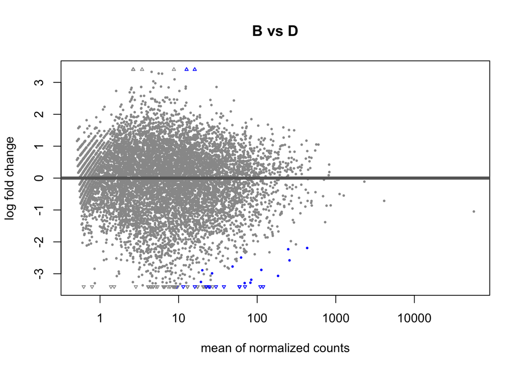

```r
plotMA(resBD, main="B vs D")
```

- Now make a table of the differential expression values (log2fc) between B and D

```r
write.table(resBD, file="BD_DE.txt", quote=F, sep="\t")
head(read.delim("BD_DE.txt"))
```

```
##             baseMean log2FoldChange    lfcSE       stat    pvalue padj
## ofav100240 0.5508525      0.2285572 2.853159 0.08010671 0.9361524   NA
## ofav105450 3.3676886      1.3653980 1.873158 0.72892820 0.4660456   NA
## ofav111453 0.5098336      1.1626775 2.943312 0.39502358 0.6928255   NA
## ofav111699 0.5191670      0.6099976 2.951201 0.20669471 0.8362483   NA
## ofav112042 0.5676167      0.2731163 2.826390 0.09663079 0.9230196   NA
## ofav112798 0.5247550      0.6248256 2.921107 0.21390028 0.8306248   NA
```

- “BD_DE.txt” contains the log2FC, the pvalue, and the padj, as well as some other data that we don’t really need
- Load tidyverse

```r
library(tidyverse)
```

- Get the p-values from your data file
- Create valBD that is a table from resBD of just the pvalues and adjusted p-values (p-adj)
- Then give the columns approprite names

```r
valBD=cbind(resBD$pvalue, resBD$padj)
head(valBD)
```

```
##           [,1] [,2]
## [1,] 0.9361524   NA
## [2,] 0.4660456   NA
## [3,] 0.6928255   NA
## [4,] 0.8362483   NA
## [5,] 0.9230196   NA
## [6,] 0.8306248   NA
```

```r
colnames(valBD)=c("pval.BD", "padj.BD")
length(valBD[,1])
```

```
## [1] 8573
```

- Return a logical vector in which both cases (pval and padj) are complete (no missing values)

```r
table(complete.cases(valBD))
```

```
##
## FALSE  TRUE
##  5002  3571
```

- Make a table (that you can visualize via assay) of the rlogdata and pvals
- Then make the column names for rld the same ones that were in colData$treat

```r
rlog=rlogTransformation(dds, blind=TRUE)
rld=assay(rlog)
head(rld)
```

```
##                   BR.A        BR.B        BR.C        DR.A        DR.C
## ofav100240 -0.18317292  0.15308730  0.04448964  0.01382183  0.05193387
## ofav105450 -0.07668887  0.41575392  1.05261483 -0.63972074  2.88779009
## ofav111453 -0.35792397 -0.03161843 -0.74308184 -0.39909254 -0.12977730
## ofav111699 -0.30100842  0.02764607 -0.32044366 -0.50483852 -0.07121941
## ofav112042 -0.17887173  0.16119687  0.05041091  0.30434686  0.05889781
## ofav112798 -0.26495065  0.06508583 -0.28610076 -0.31118027 -0.03419538
##                   DR.D
## ofav100240  0.17668962
## ofav105450 -1.18835871
## ofav111453  0.40725858
## ofav111699  0.39991365
## ofav112042 -0.08104409
## ofav112798  0.36910147
```

```r
colnames(rld)=paste(colData$treat)
head(rld)
```

```
##                      B           B           B           D           D
## ofav100240 -0.18317292  0.15308730  0.04448964  0.01382183  0.05193387
## ofav105450 -0.07668887  0.41575392  1.05261483 -0.63972074  2.88779009
## ofav111453 -0.35792397 -0.03161843 -0.74308184 -0.39909254 -0.12977730
## ofav111699 -0.30100842  0.02764607 -0.32044366 -0.50483852 -0.07121941
## ofav112042 -0.17887173  0.16119687  0.05041091  0.30434686  0.05889781
## ofav112798 -0.26495065  0.06508583 -0.28610076 -0.31118027 -0.03419538
##                      D
## ofav100240  0.17668962
## ofav105450 -1.18835871
## ofav111453  0.40725858
## ofav111699  0.39991365
## ofav112042 -0.08104409
## ofav112798  0.36910147
```

```r
length(rld[,1])
```

```
## [1] 8573
```

- Combine rld with your table of pval and padj values (valBD)

```r
rldpvals=cbind(rld,valBD)
head(rldpvals)
```

```
##                      B           B           B           D           D
## ofav100240 -0.18317292  0.15308730  0.04448964  0.01382183  0.05193387
## ofav105450 -0.07668887  0.41575392  1.05261483 -0.63972074  2.88779009
## ofav111453 -0.35792397 -0.03161843 -0.74308184 -0.39909254 -0.12977730
## ofav111699 -0.30100842  0.02764607 -0.32044366 -0.50483852 -0.07121941
## ofav112042 -0.17887173  0.16119687  0.05041091  0.30434686  0.05889781
## ofav112798 -0.26495065  0.06508583 -0.28610076 -0.31118027 -0.03419538
##                      D   pval.BD padj.BD
## ofav100240  0.17668962 0.9361524      NA
## ofav105450 -1.18835871 0.4660456      NA
## ofav111453  0.40725858 0.6928255      NA
## ofav111699  0.39991365 0.8362483      NA
## ofav112042 -0.08104409 0.9230196      NA
## ofav112798  0.36910147 0.8306248      NA
```

```r
dim(rldpvals)
```

```
## [1] 8573    8
```

```r
table(complete.cases(rldpvals))
```

```
##
## FALSE  TRUE
##  5002  3571
```

- Create a new csv file from rldpvals

```r
write.csv(rldpvals, "timmy_uptake_RLDandPVALS.csv", quote=F)
```

- Now we will create a heatmap of sample distances based on pvalues
- Make a new variable for your csv file

```r
rldpvals <- read.csv(file="timmy_uptake_RLDandPVALS.csv", row.names=1)
head(rldpvals)
```

```
##                      B         B.1         B.2           D         D.1
## ofav100240 -0.18317292  0.15308730  0.04448964  0.01382183  0.05193387
## ofav105450 -0.07668887  0.41575392  1.05261483 -0.63972074  2.88779009
## ofav111453 -0.35792397 -0.03161843 -0.74308184 -0.39909254 -0.12977730
## ofav111699 -0.30100842  0.02764607 -0.32044366 -0.50483852 -0.07121941
## ofav112042 -0.17887173  0.16119687  0.05041091  0.30434686  0.05889781
## ofav112798 -0.26495065  0.06508583 -0.28610076 -0.31118027 -0.03419538
##                    D.2   pval.BD padj.BD
## ofav100240  0.17668962 0.9361524      NA
## ofav105450 -1.18835871 0.4660456      NA
## ofav111453  0.40725858 0.6928255      NA
## ofav111699  0.39991365 0.8362483      NA
## ofav112042 -0.08104409 0.9230196      NA
## ofav112798  0.36910147 0.8306248      NA
```

- Make rld that a variable that just returns the first six columns with values (rownames then columns 1-6)

```r
rld=rldpvals[,1:6]
head(rld)
```

```
##                      B         B.1         B.2           D         D.1
## ofav100240 -0.18317292  0.15308730  0.04448964  0.01382183  0.05193387
## ofav105450 -0.07668887  0.41575392  1.05261483 -0.63972074  2.88779009
## ofav111453 -0.35792397 -0.03161843 -0.74308184 -0.39909254 -0.12977730
## ofav111699 -0.30100842  0.02764607 -0.32044366 -0.50483852 -0.07121941
## ofav112042 -0.17887173  0.16119687  0.05041091  0.30434686  0.05889781
## ofav112798 -0.26495065  0.06508583 -0.28610076 -0.31118027 -0.03419538
##                    D.2
## ofav100240  0.17668962
## ofav105450 -1.18835871
## ofav111453  0.40725858
## ofav111699  0.39991365
## ofav112042 -0.08104409
## ofav112798  0.36910147
```

- dist computes and returns the distance matrix computed using the specified distance measure to compute distances between the rows of a data matrix (rld); determine the overall differences in expression between each sample
- Turn the distances into a matrix

```r
sampleDists <- dist(t(rld))
sampleDistMatrix <- as.matrix(sampleDists)
```

- Create a vector of treatment titles for the matrix and apply them to the rows and columns

```r
treat=c("B", "B", "B", "D", "D", "D")
colnames(sampleDistMatrix)=paste(treat)
rownames(sampleDistMatrix)=paste(treat)
```

- Install some packages to make heatmaps

```r
install.packages("pheatmap", repos='http://cran.us.r-project.org')
library("pheatmap")
heat.colors = colorRampPalette(rev(c("blue","yellow")),bias=0.3)(100)
quartz()
```

- Apply your matrix of overall expression distance to a heatmap

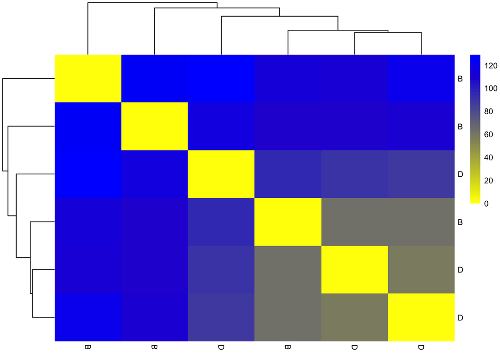

```r
pheatmap(sampleDistMatrix,color = heat.colors,cex=0.9,border_color=NA,cluster_rows=T,cluster_cols=T)
```

- Load some more packages for the next steps (PCA)

```r
library(vegan)
library(ggplot2)
library(ggrepel)
library(tidyverse)
```

- Now going to perform PCA on the data to visualize overall effect of experimental covariates and batch effects
- t hides all the columns somehow and just shows the gene identifiers?? I’m not really sure tho, maybe just shows me the rownames

```r
rld_t=t(rld)
head(rld)
```

```
##                      B         B.1         B.2           D         D.1
## ofav100240 -0.18317292  0.15308730  0.04448964  0.01382183  0.05193387
## ofav105450 -0.07668887  0.41575392  1.05261483 -0.63972074  2.88779009
## ofav111453 -0.35792397 -0.03161843 -0.74308184 -0.39909254 -0.12977730
## ofav111699 -0.30100842  0.02764607 -0.32044366 -0.50483852 -0.07121941
## ofav112042 -0.17887173  0.16119687  0.05041091  0.30434686  0.05889781
## ofav112798 -0.26495065  0.06508583 -0.28610076 -0.31118027 -0.03419538
##                    D.2
## ofav100240  0.17668962
## ofav105450 -1.18835871
## ofav111453  0.40725858
## ofav111699  0.39991365
## ofav112042 -0.08104409
## ofav112798  0.36910147
```

```r
head(rld_t)
```

- prcomp performs a pca on given data matrix and returns results as an object of class prcomp

```r
pca <- prcomp(rld_t,center = TRUE, scale. = TRUE, na.action=na.omit)
head(pca)
```

- sdev is the standard deviations of the principal components
- Using the sdev, calculate the proportion that each PC corresponds to the variance
- Then round PC1 and PC2 (times 100, to 1 sigfig)

```r
li <- pca$sdev^2 / sum(pca$sdev^2)
pc1v <- round(li[1] * 100, 1)
pc2v <- round(li[2] * 100, 1)
```

- x from prcomp seems like it’s the coordinates of each treatment in the PCA
- turn pca$x into a dataframe

```r
pca_s <- as.data.frame(pca$x)
head(pca_s)
```

```
##            PC1        PC2         PC3        PC4          PC5           PC6
## B   -107.43871  24.744680  -0.6350711  -0.753180   5.94017444  1.075842e-13
## B.1   -6.19861 -89.459208 -23.4116037   2.263193  -0.08413821 -2.400904e-13
## B.2   30.68753  25.845752 -33.7552195 -50.664161 -12.76503097 -1.173367e-14
## D     22.95094  24.845198 -12.9628644  42.405397 -36.48590296 -8.849041e-15
## D.1   19.21853  -7.827036  81.8942316 -11.103275  -4.50512345  6.954913e-14
## D.2   40.78031  21.850614 -11.1294729  17.852026  47.90002114  1.295570e-13
```

- Just take PC1 and PC2 and add your sample and treatment names

```r
pca_s <- pca_s[,c(1,2)]
head(pca_s)
```

```
##            PC1        PC2
## B   -107.43871  24.744680
## B.1   -6.19861 -89.459208
## B.2   30.68753  25.845752
## D     22.95094  24.845198
## D.1   19.21853  -7.827036
## D.2   40.78031  21.850614
```

```r
pca_s$Samples = row.names(pca_s)
head(pca_s)
```

```
##            PC1        PC2 Samples
## B   -107.43871  24.744680       B
## B.1   -6.19861 -89.459208     B.1
## B.2   30.68753  25.845752     B.2
## D     22.95094  24.845198       D
## D.1   19.21853  -7.827036     D.1
## D.2   40.78031  21.850614     D.2
```

```r
pca_s$treat=colData$treat
head(pca_s)
```

```
##            PC1        PC2 Samples treat
## B   -107.43871  24.744680       B     B
## B.1   -6.19861 -89.459208     B.1     B
## B.2   30.68753  25.845752     B.2     B
## D     22.95094  24.845198       D     D
## D.1   19.21853  -7.827036     D.1     D
## D.2   40.78031  21.850614     D.2     D
```

- Creating your PCA plot
- aes is aesthetic mappings, how variables are mapped to visual properties

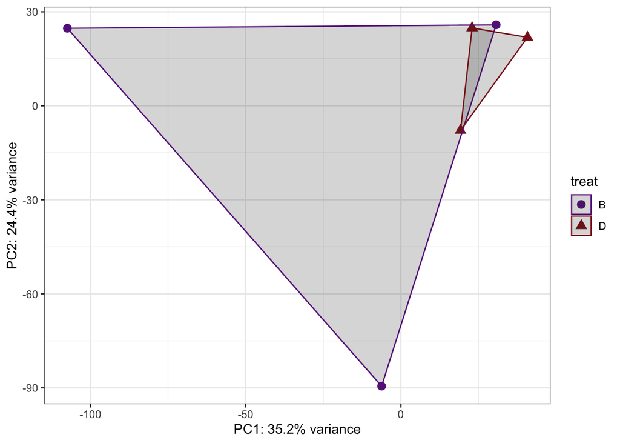

```r
cbPalette <- c("darkorchid4","firebrick4")
ggplot(pca_s, aes(PC1, PC2, color = treat, pch = treat)) +
  geom_point(size=3) +
  #  geom_text_repel(aes(label=Samples)) +
  scale_colour_manual(values=cbPalette)+
  theme_bw() +
  # geom_density2d(alpha=.5)+
  geom_polygon(alpha=.2)+
  xlab(paste0("PC1: ",pc1v,"% variance")) +
  ylab(paste0("PC2: ",pc2v,"% variance"))
```

- You can see from this plot that the B samples have very high variance and that there’s some overlap between the samples
- I’m skipping the adonis part because it gave me an error and doesn’t seem that important

ACTUAL DIFFERENTIAL GENE EXPRESSION ANALYSIS STARTS HERE - This is just the preliminary GO enrichment analysis of all the genes. The way gomwu works is that it performs rankings and gives you enrichment of GO terms in the ranked list. So GO terms that show up may not actually contain only genes that are significantly differentially expressed, that gene set is just enriched

- Plotting genes within each GO category between B and D
- MF: Molecular function
- BP: Biological process
- CC: Cellular component
- Manipulated BD_DE.txt in excel following Sarah’s verbal instructions and loaded it here
- BD_DE_GO has the -log(p-values)
- From the timmy_uptake file, we got log2 fold change (MLE): treat D vs B
- Reminder: this means that pos log2FC values indicate D is upregulated compared to B; The name provided in the second element (B) is the baseline

```r
BD_DE_GO = read.csv("BD_DE_GO.csv")
```

- Creating dendrograms (more info can be found in the r file GO_MWU.R)
- First, run MF; edit the input stuff to match what you’re running
- BD_DE_GO.csv has two columns of comma-separated values: gene id, continuous measure of significance. To perform standard GO enrichment analysis based on Fisher’s exact test, use binary measure (0 or 1, i.e., either significant or not).
- orb_fav_iso2go.txt is two-column, tab-delimited, one line per gene, multiple GO terms separated by semicolon. If you have multiple lines per gene, use nrify_GOtable.pl prior to running this script.
- go.obo is downloaded from http://www.geneontology.org/GO.downloads.ontology.shtml
- goDivision is either MF, BP, or CC

```r
head(read.csv("BD_DE_GO.csv"))
```

```
##        gene      pval
## 1 ofav43965 -7.438086
## 2 ofav39923 -6.469170
## 3 ofav46740 -5.510425
## 4  ofav6787 -4.711329
## 5 ofav34835 -4.411774
## 6 ofav46698 -4.297164
```

```r
input="BD_DE_GO.csv"
goAnnotations="orb_fav_iso2go.txt"
goDatabase="go.obo"
goDivision="MF"
source("gomwu.functions.R")
```

- Calculating stats. It might take ~3 min for MF and BP. Do not rerun it if you just want to replot the data with different cutoffs, go straight to gomwuPlot. If you change any of the numeric values below, delete the files that were generated in previous runs first.
- perlPath: replace with full path to perl executable if it is not in your system’s PATH already
- largest: a GO category will not be considered if it contains more than this fraction of the total number of genes
- smallest: a GO category should contain at least this many genes to be considered
- clusterCutHeight: threshold for merginng similar (gene-sharing) terms. See gomwu README for details

```r
gomwuStats(input, goDatabase, goAnnotations, goDivision,
           perlPath="perl",
           largest=0.1,
           smallest=5,
           clusterCutHeight=0.25)
```

```
## Continuous measure of interest: will perform MWU test
## 9  GO terms at 10% FDR
```

- Returned 9 GO terms at 10% FDR
- Plot results in a dendrogram
- absValue=-log(0.05,10); genes with the measure value exceeding this will be counted as “good genes”. Specify absValue=0.001 if you are doing Fisher’s exact test for standard GO enrichment or analyzing a WGCNA module (all non-zero genes = “good genes”).
- level1=0.1: FDR threshold for plotting. Specify level1=1 to plot all GO categories containing genes exceeding the absValue.
- level2=0.05: FDR cutoff to print in regular (not italic) font.
- level3=0.01: FDR cutoff to print in large bold font.
- txtsize=1.5: decrease to fit more on one page, or increase (after rescaling the plot so the tree fits the text) for better “word cloud” effect
- treeHeight=0.5: height of the hierarchical clustering tree
- colors=c(“dodgerblue2”,“firebrick1”,“skyblue”,“lightcoral”) # these are default colors, un-remark and change if needed
- Typing resultsMF gives you the data in a written format

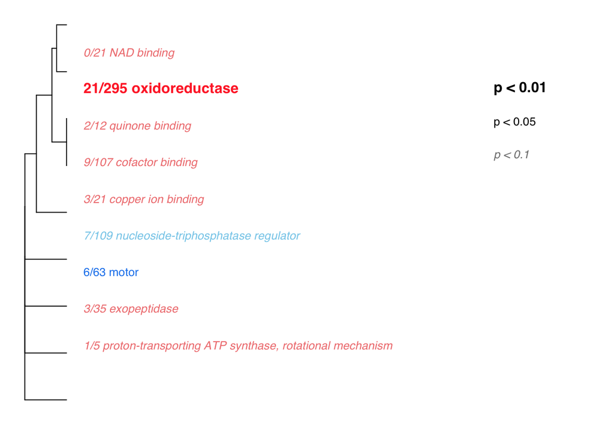

```
## GO terms dispayed:  9
## "Good genes" accounted for:  43 out of 277 ( 16% )
```

```r
quartz()
resultsMF=gomwuPlot(input,goAnnotations,goDivision,
                  absValue=1,
                  level1=0.1,
                  level2=0.05,
                  level3=0.01,
                  txtsize=1.5,
                  treeHeight=0.5,
)
```

```r
resultsMF
```

```
##                                                                            pval
## 1/5 proton-transporting ATP synthase activity, rotational mechanism 0.093285683
## 3/35 exopeptidase activity                                          0.056794793
## 6/63 motor activity                                                 0.038778057
## 7/109 nucleoside-triphosphatase regulator activity                  0.092515096
## 3/21 copper ion binding                                             0.092515096
## 9/107 cofactor binding                                              0.083884094
## 2/12 quinone binding                                                0.083884094
## 21/295 oxidoreductase activity                                      0.004519317
## 0/21 NAD binding                                                    0.083884094
##                                                                     direction
## 1/5 proton-transporting ATP synthase activity, rotational mechanism         1
## 3/35 exopeptidase activity                                                  1
## 6/63 motor activity                                                         0
## 7/109 nucleoside-triphosphatase regulator activity                          0
## 3/21 copper ion binding                                                     1
## 9/107 cofactor binding                                                      1
## 2/12 quinone binding                                                        1
## 21/295 oxidoreductase activity                                              1
## 0/21 NAD binding                                                            1
##                                                                           color
## 1/5 proton-transporting ATP synthase activity, rotational mechanism  lightcoral
## 3/35 exopeptidase activity                                           lightcoral
## 6/63 motor activity                                                 dodgerblue2
## 7/109 nucleoside-triphosphatase regulator activity                      skyblue
## 3/21 copper ion binding                                              lightcoral
## 9/107 cofactor binding                                               lightcoral
## 2/12 quinone binding                                                 lightcoral
## 21/295 oxidoreductase activity                                       firebrick1
## 0/21 NAD binding                                                     lightcoral
```

- Doesn’t look that pretty, but if you really want it to look nice, run the above code in base R and then you can manipulate the size of the image to your liking, or export it as a pdf and fiddle around with the size
- Red is upregulated in D and blue is downregulated in D (upregulated in B)
- The GO term we are most interested in here is Oxidoreductase, remember this for later
- Now let’s run the above protocol for BP

```r
head(read.csv("BD_DE_GO.csv"))
```

```
##        gene      pval
## 1 ofav43965 -7.438086
## 2 ofav39923 -6.469170
## 3 ofav46740 -5.510425
## 4  ofav6787 -4.711329
## 5 ofav34835 -4.411774
## 6 ofav46698 -4.297164
```

```r
input="BD_DE_GO.csv"
goAnnotations="orb_fav_iso2go.txt"
goDatabase="go.obo"
goDivision="BP"
source("gomwu.functions.R")

gomwuStats(input, goDatabase, goAnnotations, goDivision,
           perlPath="perl",
           largest=0.1,
           smallest=5,
           clusterCutHeight=0.25)
```

```
## Continuous measure of interest: will perform MWU test
## 6  GO terms at 10% FDR
```

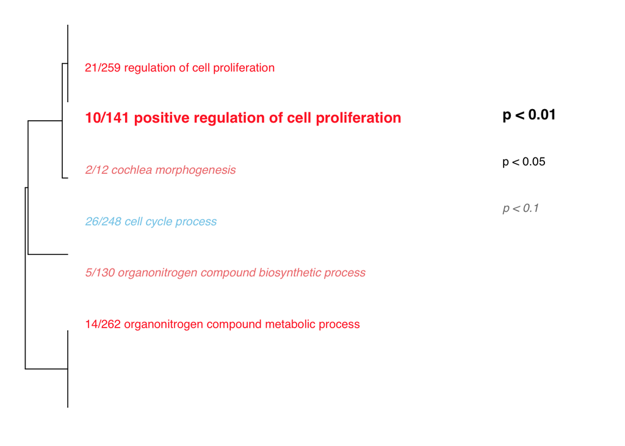

```
## GO terms dispayed:  6
## "Good genes" accounted for:  56 out of 282 ( 20% )
```

```r
quartz()
resultsBP=gomwuPlot(input,goAnnotations,goDivision,
                  absValue=1,
                  level1=0.1,
                  level2=0.05,
                  level3=0.01,
                  txtsize=1.5,
                  treeHeight=0.5,
)
```

```r
resultsBP
```

```
##                                                           pval direction
## 14/262 organonitrogen compound metabolic process   0.020455732         1
## 5/130 organonitrogen compound biosynthetic process 0.057009061         1
## 26/248 cell cycle process                          0.074113542         0
## 2/12 cochlea morphogenesis                         0.074113542         1
## 10/141 positive regulation of cell proliferation   0.002570056         1
## 21/259 regulation of cell proliferation            0.036717791         1
##                                                         color
## 14/262 organonitrogen compound metabolic process   firebrick1
## 5/130 organonitrogen compound biosynthetic process lightcoral
## 26/248 cell cycle process                             skyblue
## 2/12 cochlea morphogenesis                         lightcoral
## 10/141 positive regulation of cell proliferation   firebrick1
## 21/259 regulation of cell proliferation            firebrick1
```

- Returned 6 GO terms at 10% FDR
- Here we are interested in the positive regulation of cell proliferation
- Now let’s run it for CC

```r
head(read.csv("BD_DE_GO.csv"))
```

```
##        gene      pval
## 1 ofav43965 -7.438086
## 2 ofav39923 -6.469170
## 3 ofav46740 -5.510425
## 4  ofav6787 -4.711329
## 5 ofav34835 -4.411774
## 6 ofav46698 -4.297164
```

```r
input="BD_DE_GO.csv"
goAnnotations="orb_fav_iso2go.txt"
goDatabase="go.obo"
goDivision="CC"
source("gomwu.functions.R")

gomwuStats(input, goDatabase, goAnnotations, goDivision,
           perlPath="perl",
           largest=0.1,
           smallest=5,
           clusterCutHeight=0.25)
```

```
## Continuous measure of interest: will perform MWU test
## 18  GO terms at 10% FDR
```

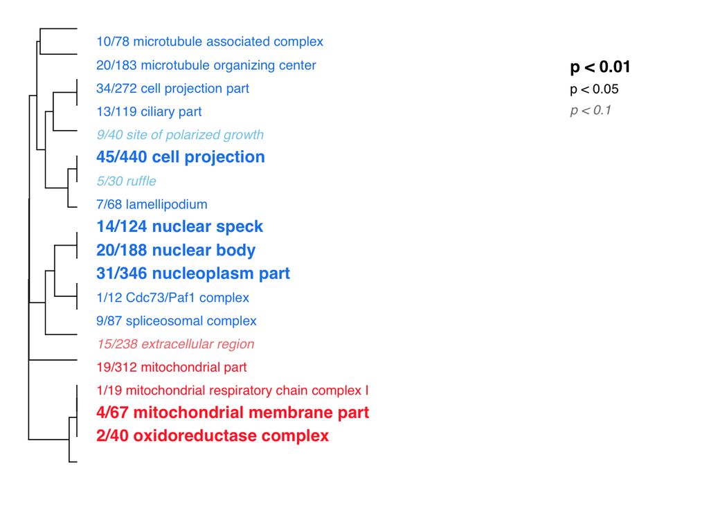

```
## GO terms dispayed:  18
## "Good genes" accounted for:  134 out of 305 ( 44% )
```

```r
quartz()
resultsCC=gomwuPlot(input,goAnnotations,goDivision,
                  absValue=1,
                  level1=0.1,
                  level2=0.05,
                  level3=0.01,
                  txtsize=1.5,
                  treeHeight=0.5,
)
```

```r
resultsCC
```

```
##                                                        pval direction
## 2/40 oxidoreductase complex                    0.0041198445         1
## 4/67 mitochondrial membrane part               0.0020818115         1
## 1/19 mitochondrial respiratory chain complex I 0.0360081332         1
## 19/312 mitochondrial part                      0.0304049483         1
## 15/238 extracellular region                    0.0762663791         1
## 9/87 spliceosomal complex                      0.0142177708         0
## 1/12 Cdc73/Paf1 complex                        0.0304049483         0
## 31/346 nucleoplasm part                        0.0011089789         0
## 20/188 nuclear body                            0.0005861776         0
## 14/124 nuclear speck                           0.0005861776         0
## 7/68 lamellipodium                             0.0142177708         0
## 5/30 ruffle                                    0.0762663791         0
## 45/440 cell projection                         0.0041198445         0
## 9/40 site of polarized growth                  0.0659524983         0
## 13/119 ciliary part                            0.0360081332         0
## 34/272 cell projection part                    0.0325288444         0
## 20/183 microtubule organizing center           0.0304049483         0
## 10/78 microtubule associated complex           0.0115337909         0
##                                                      color
## 2/40 oxidoreductase complex                     firebrick1
## 4/67 mitochondrial membrane part                firebrick1
## 1/19 mitochondrial respiratory chain complex I  firebrick1
## 19/312 mitochondrial part                       firebrick1
## 15/238 extracellular region                     lightcoral
## 9/87 spliceosomal complex                      dodgerblue2
## 1/12 Cdc73/Paf1 complex                        dodgerblue2
## 31/346 nucleoplasm part                        dodgerblue2
## 20/188 nuclear body                            dodgerblue2
## 14/124 nuclear speck                           dodgerblue2
## 7/68 lamellipodium                             dodgerblue2
## 5/30 ruffle                                        skyblue
## 45/440 cell projection                         dodgerblue2
## 9/40 site of polarized growth                      skyblue
## 13/119 ciliary part                            dodgerblue2
## 34/272 cell projection part                    dodgerblue2
## 20/183 microtubule organizing center           dodgerblue2
## 10/78 microtubule associated complex           dodgerblue2
```

- Returned 18 GO terms of interest
- Interested in the oxidoreductase complex

INVESTIGATING DIFFERENTIAL EXPRESSION OF GENES IN SPECIFIC GO CATEGORIES - Using Dan Wuitchik’s code: https://github.com/wuitchik/Divergent-thermal-challenges-elicit-convergent-stress-signatures-in-aposymbiotic-Astrangia-poculata/blob/master/Astrangia_HotCold.pdf - First, looking at positive regulation of cell proliferation (from BP, GO:0008284) - Load packages - Set up the variable iso2go which contains the ofav gene id and all of its associated GO terms

```r
library(tidyverse)
library(dplyr)
```

```r
iso2go = read.delim("orb_fav_iso2go.txt")
head(iso2go)
```

```
##      Gene_id
## 1 ofav141339
## 2  ofav71425
## 3  ofav58561
## 4  ofav60863
## 5  ofav51466
## 6  ofav36231
##                                                                                                                                                                                     GO.terms
## 1                                                                                                               GO:0000790;GO:0031491;GO:0003714;GO:0016569;GO:0006336;GO:0031935;GO:0006351
## 2                                                                                                                                     GO:0005783;GO:0005524;GO:0016887;GO:0046872;GO:0006810
## 3 GO:0031461;GO:0005737;GO:0005634;GO:0031625;GO:0031145;GO:0008595;GO:0008105;GO:0030261;GO:0042078;GO:0019100;GO:0019102;GO:0051232;GO:0007067;GO:1902104;GO:0042787;GO:0051759;GO:0036369
## 4                                                                                                                                     GO:0005737;GO:0002161;GO:0005524;GO:0004832;GO:0006438
## 5                                                                                                    GO:0005829;GO:0005634;GO:0005685;GO:0071004;GO:0003729;GO:0000395;GO:0045292;GO:0006376
## 6                                                                   GO:0016021;GO:0043231;GO:0042470;GO:0033162;GO:0048471;GO:0005507;GO:0004503;GO:0008283;GO:0042438;GO:0043473;GO:0048538
```

- Obtain the gene symbol from the gene descriptions in the file orb_fav_iso2gene.tab
- Create the variable gene which contains the gene id, the full description, and the gene symbol

```r
gene = read.delim("orb_fav_iso2gene.tab", sep = "\t")%>%
       mutate(gene_symbol = gsub(".* GN=", "", Description)) %>%
       mutate(gene_symbol = gsub(" .*", "", gene_symbol))

head(gene)
```

```
##      Gene_id
## 1 ofav141339
## 2  ofav71425
## 3  ofav58561
## 4  ofav60863
## 5  ofav51466
## 6  ofav36231
##                                                                                                                     Description
## 1                                                               Protein HIRA OS=Gallus gallus GN=HIRA PE=1 SV=2 E(blastx)=7e-34
## 2                                        ATPase ASNA1 homolog OS=Nematostella vectensis GN=v1g161623 PE=3 SV=1 E(blastx)=5e-108
## 3                                                        Cullin-2 OS=Caenorhabditis elegans GN=cul-2 PE=1 SV=3 E(blastx)=3e-166
## 4                                                   Valine--tRNA ligase OS=Takifugu rubripes GN=vars PE=3 SV=1 E(blastx)=7e-147
## 5 U1 snRNP-associated protein usp106 OS=Schizosaccharomyces pombe (strain 972 / ATCC 24843) GN=usp106 PE=1 SV=1 E(blastx)=9e-20
## 6                                                                 Tyrosinase OS=Gallus gallus GN=TYR PE=2 SV=1 E(blastx)=3e-118
##   gene_symbol
## 1        HIRA
## 2   v1g161623
## 3       cul-2
## 4        vars
## 5      usp106
## 6         TYR
```

- To get the rlog foldchange values, I’m going to manipulate the timmy uptake file (which I will save in a variable called BD_DE)

```r
head(read.csv("timmy_uptake_RLDandPVALS.csv"))
```

```
##            X           B         B.1         B.2           D         D.1
## 1 ofav100240 -0.18317292  0.15308730  0.04448964  0.01382183  0.05193387
## 2 ofav105450 -0.07668887  0.41575392  1.05261483 -0.63972074  2.88779009
## 3 ofav111453 -0.35792397 -0.03161843 -0.74308184 -0.39909254 -0.12977730
## 4 ofav111699 -0.30100842  0.02764607 -0.32044366 -0.50483852 -0.07121941
## 5 ofav112042 -0.17887173  0.16119687  0.05041091  0.30434686  0.05889781
## 6 ofav112798 -0.26495065  0.06508583 -0.28610076 -0.31118027 -0.03419538
##           D.2   pval.BD padj.BD
## 1  0.17668962 0.9361524      NA
## 2 -1.18835871 0.4660456      NA
## 3  0.40725858 0.6928255      NA
## 4  0.39991365 0.8362483      NA
## 5 -0.08104409 0.9230196      NA
## 6  0.36910147 0.8306248      NA
```

```r
BD_DE = read.csv("timmy_uptake_RLDandPVALS.csv")

head(BD_DE)
```

```
##            X           B         B.1         B.2           D         D.1
## 1 ofav100240 -0.18317292  0.15308730  0.04448964  0.01382183  0.05193387
## 2 ofav105450 -0.07668887  0.41575392  1.05261483 -0.63972074  2.88779009
## 3 ofav111453 -0.35792397 -0.03161843 -0.74308184 -0.39909254 -0.12977730
## 4 ofav111699 -0.30100842  0.02764607 -0.32044366 -0.50483852 -0.07121941
## 5 ofav112042 -0.17887173  0.16119687  0.05041091  0.30434686  0.05889781
## 6 ofav112798 -0.26495065  0.06508583 -0.28610076 -0.31118027 -0.03419538
##           D.2   pval.BD padj.BD
## 1  0.17668962 0.9361524      NA
## 2 -1.18835871 0.4660456      NA
## 3  0.40725858 0.6928255      NA
## 4  0.39991365 0.8362483      NA
## 5 -0.08104409 0.9230196      NA
## 6  0.36910147 0.8306248      NA
```

```r
rlog_BD = BD_DE[,1:7] %>%
  rename(Gene_id = X)
head(rlog_BD)
```

```
##      Gene_id           B         B.1         B.2           D         D.1
## 1 ofav100240 -0.18317292  0.15308730  0.04448964  0.01382183  0.05193387
## 2 ofav105450 -0.07668887  0.41575392  1.05261483 -0.63972074  2.88779009
## 3 ofav111453 -0.35792397 -0.03161843 -0.74308184 -0.39909254 -0.12977730
## 4 ofav111699 -0.30100842  0.02764607 -0.32044366 -0.50483852 -0.07121941
## 5 ofav112042 -0.17887173  0.16119687  0.05041091  0.30434686  0.05889781
## 6 ofav112798 -0.26495065  0.06508583 -0.28610076 -0.31118027 -0.03419538
##           D.2
## 1  0.17668962
## 2 -1.18835871
## 3  0.40725858
## 4  0.39991365
## 5 -0.08104409
## 6  0.36910147
```

- rlog_BD just has the isoform names (called Gene_id) and the log2FC for each sample
- could have also used the tidyverse select function instead of [,1:7] here, Dan says it’s better to keep the same format so using select would have been better
- Next, make a variable that contains all the genes that correspond to GO:0008284

```r
GO_0008284 = iso2go %>%
  filter(str_detect(GO.terms, "GO:0008284")) %>%
  left_join(rlog_BD) %>%
  left_join(gene) %>%
  mutate(gene_symbol = make.names(gene_symbol, unique = TRUE)) %>%
  column_to_rownames(var = "gene_symbol") %>%
  dplyr::select(-GO.terms, -Description, -Gene_id) %>%
  drop_na() %>%
  dplyr::select(sort(current_vars()))
head(GO_0008284)
```

```
##               B      B.1      B.2         D       D.1      D.2
## EFNB2 2.6990638 4.410488 4.689127 4.7266959 4.1540731 5.087185
## Traf5 4.1009740 5.428181 5.056108 5.5270799 5.9621205 5.938174
## Hsf1  6.1573006 5.740615 7.070304 7.5143549 7.1483076 7.120657
## Crkl  5.4989591 5.355513 6.147743 6.0620991 6.0696958 6.416316
## Ddr2  2.9895301 2.182014 4.051328 4.4024427 3.5446713 4.448772
## DERL2 0.4614182 2.108024 1.533612 0.9824551 0.7999604 2.000090
```

```r
colnames(rlog_BD)
```

```
## [1] "Gene_id" "B"       "B.1"     "B.2"     "D"       "D.1"     "D.2"
```

- Plot a heatmap of the differential expression of ALL the genes that correspond to GO_0008284 pos reg of cell prolif

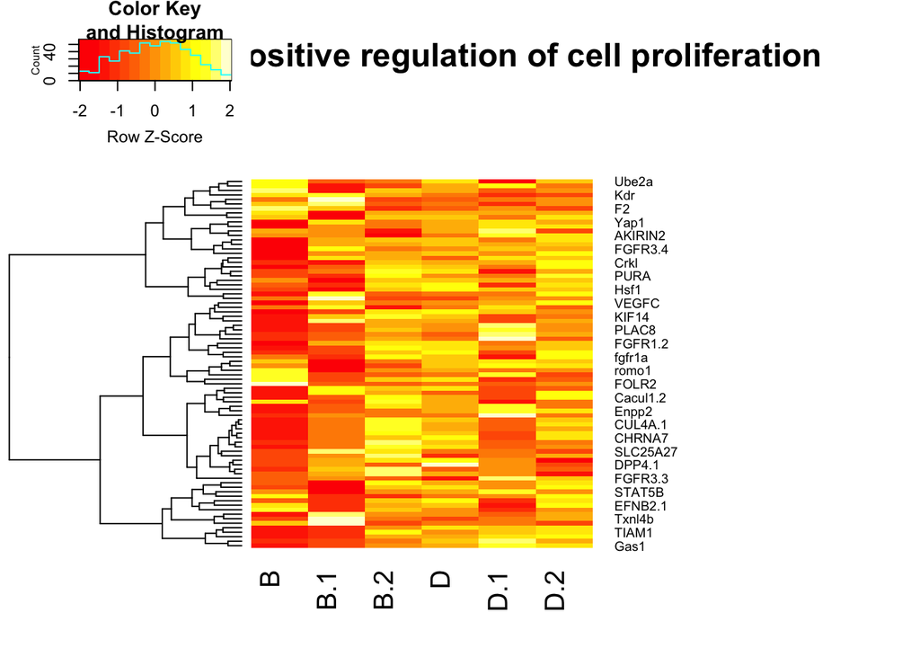

```r
library(gplots)
heatmap_GO_0008284 = heatmap.2(as.matrix(GO_0008284), Rowv = TRUE, Colv = FALSE, scale = "row",
          dendrogram = "both",
          trace = "none",
          main = "GO_0008284 positive regulation of cell proliferation",
          margin = c(5,15))
```

- Yellow to white correspond to upregulation and red corresponds to downregulation
- Now doing the same for oxidoreductase
- Oxidoreductase complex from CC (GO:1990204); oxidoreductase activity (GO:0016491); oxidoreductase activity, acting on paired donors etc. (GO:0016715)
- To filter for multiple terms, use | (the symbol that is shift back slash) and quotes only outside all the terms

```r
oxidoreductase = iso2go %>%
  filter(str_detect(GO.terms, "GO:1990204|GO:0016491|GO:0016715")) %>%
  left_join(rlog_BD) %>%
  left_join(gene) %>%
  mutate(gene_symbol = make.names(gene_symbol, unique = TRUE)) %>%
  column_to_rownames(var = "gene_symbol") %>%
  dplyr::select(-GO.terms, -Description, -Gene_id) %>%
  drop_na() %>%
  dplyr::select(sort(current_vars()))
head(oxidoreductase)
```

```
##                  B      B.1      B.2        D      D.1      D.2
## AIFM3    4.0909560 4.674521 5.363457 5.589528 6.306370 5.755526
## vat1     3.6085803 4.480263 3.653118 3.641340 1.888915 2.797876
## DES1     2.8998585 2.023060 3.697894 3.926158 3.876116 3.430575
## P100.11E 0.8892140 1.377094 3.205340 2.673762 2.331370 2.161565
## CREG2    0.9203998 1.408217 2.625504 2.833611 3.036393 2.176921
## Pyroxd1  3.0444119 1.586754 2.484778 2.773253 3.163771 1.947959
```

Plot a heatmap of the differential expression of ALL the genes that correspond to the oxidoreductase GO terms above

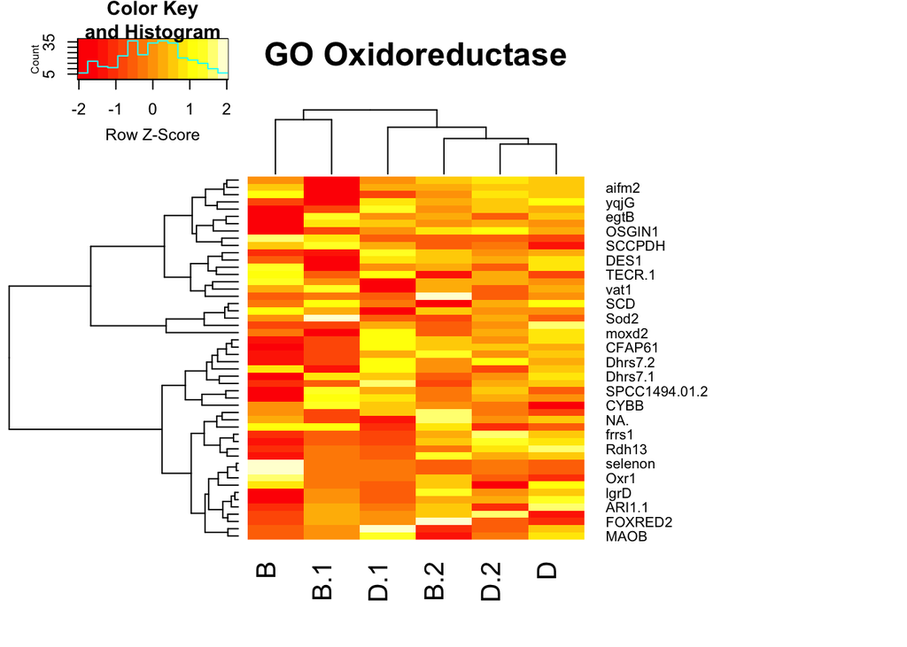

```r
heatmap_oxidoreductase = heatmap.2(as.matrix(oxidoreductase), Rowv = TRUE, Colv = TRUE, scale = "row",
                               dendrogram = "both",
                               trace = "none",
                               main = "GO Oxidoreductase",
                               margin = c(5,15))
```

- Notice that in the above heatmaps, we clustered the columns (the samples) as well as the rows. When we clustered the columns in the oxidoreductase heatmap, B.2 clusters with the Ds. This may be an affect of the count values we obtained from each sample, as B.2 was the B sample with the high count values.
- One way to mitigate this is to take the means of the rows, subtract the mean from the original value, and plot the result instead of the original value
- We’ll also be filtering for only those genes that are significantly differentially expressed between recruits hosting D vs B
- Now we want to make new heatmaps of just those genes in cell prolif and oxidoreductase that are significantly differentially expressed (we will use an alpha of 0.1)
- Filter the timmy uptake data for all genes significantly differentially expressed (alpha = 0.1 for this section, we will use the more stringent 0.05 later)

```r
BD_DE_10 = filter(BD_DE, pval.BD <= 0.1, preserve = TRUE)
head(BD_DE_10)
```

```
##           X          B       B.1        B.2          D       D.1        D.2
## 1 ofav12680 3.90133827 0.5344855 -0.2512211 -0.6238076 0.3815352 -0.2312006
## 2 ofav16930 3.02450601 0.5620672  0.4274120 -0.5028569 0.4150091  0.0363226
## 3 ofav25617 3.18159535 1.9685145  0.1416015  0.2885600 0.5875111 -0.3165155
## 4 ofav27005 2.67234533 0.4876459  0.7755144 -0.9128296 0.3432648 -0.1800952
## 5 ofav11857 0.12290057 4.6368761  0.4413966 -0.2855968 0.4878168 -0.4706502
## 6 ofav41223 0.05808605 0.5501155 -0.4900172  0.1952546 2.9584595  0.5732075
##       pval.BD   padj.BD
## 1 0.007493289        NA
## 2 0.051424944        NA
## 3 0.024907553        NA
## 4 0.048623129        NA
## 5 0.001299003 0.1449606
## 6 0.092943899        NA
```

```r
rlog_BD_10 = BD_DE_10[,1:7] %>%
  rename(Gene_id = X)
head(rlog_BD_10)
```

```
##     Gene_id          B       B.1        B.2          D       D.1        D.2
## 1 ofav12680 3.90133827 0.5344855 -0.2512211 -0.6238076 0.3815352 -0.2312006
## 2 ofav16930 3.02450601 0.5620672  0.4274120 -0.5028569 0.4150091  0.0363226
## 3 ofav25617 3.18159535 1.9685145  0.1416015  0.2885600 0.5875111 -0.3165155
## 4 ofav27005 2.67234533 0.4876459  0.7755144 -0.9128296 0.3432648 -0.1800952
## 5 ofav11857 0.12290057 4.6368761  0.4413966 -0.2855968 0.4878168 -0.4706502
## 6 ofav41223 0.05808605 0.5501155 -0.4900172  0.1952546 2.9584595  0.5732075
```

- rlog_BD_10 has all the genes that are sig DE with alpha=0.1 and does not contain the p-val nor the adj p-val
- Now search within this list for all genes that correspond to the GO term for pos reg of cell prolif and call this new list GO_0008284_sig

```r
GO_0008284_sig = iso2go %>%
  filter(str_detect(GO.terms, "GO:0008284")) %>%
  left_join(rlog_BD_10) %>%
  left_join(gene) %>%
  mutate(gene_symbol = make.names(gene_symbol, unique = TRUE)) %>%
  column_to_rownames(var = "gene_symbol") %>%
  dplyr::select(-GO.terms, -Description, -Gene_id) %>%
  drop_na() %>%
  dplyr::select(sort(current_vars()))
GO_0008284_sig
```

```
##              B      B.1       B.2        D      D.1      D.2
## N.2   1.258249 1.758614 2.3256184 3.621391 4.958816 3.218951
## gata3 1.636073 2.182995 4.0166781 3.964203 4.778018 5.162891
## SelD  1.410756 1.917774 3.2760951 4.135901 3.829358 4.247367
## FOLR2 4.439381 1.168060 0.8639565 1.359882 1.012465 1.709655
## F2    7.297177 6.066189 4.3440219 5.041438 5.655450 4.729713
## Gas1  1.248697 1.744827 2.8138226 3.147028 4.345456 3.610875
```

- We have 6 genes, plot them in a heatmap but this time use the calculated difference from the mean

```r
GO_0008284_means_sig = apply(GO_0008284_sig, 1, mean)
explc_cellprolif = GO_0008284_sig-GO_0008284_means_sig
head(explc_cellprolif)
```

```
##               B        B.1          B.2          D        D.1         D.2
## N.2   -1.598691 -1.0983256 -0.531321411  0.7644508  2.1018759  0.36201145
## gata3 -1.987404 -1.4404815  0.393201813  0.3407265  1.1545417  1.53941505
## SelD  -1.725452 -1.2184343  0.139886625  0.9996928  0.6931492  1.11115809
## FOLR2  2.680481 -0.5908393 -0.894943267 -0.3990182 -0.7464352 -0.04924489
## F2     1.774846  0.5438576 -1.178309549 -0.4808931  0.1331182 -0.79261883
## Gas1  -1.569754 -1.0736243 -0.004628391  0.3285770  1.5270052  0.79242440
```

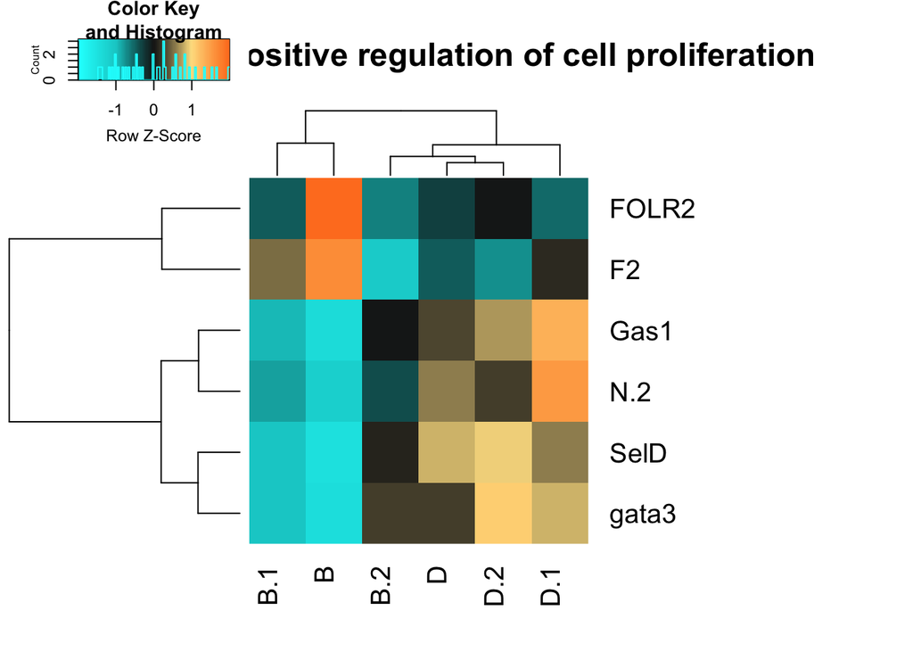

```r
col0=colorRampPalette(rev(c("chocolate1","#FEE090","grey10", "cyan3","cyan")))(100)
heatmap_GO_0008284_sig = heatmap.2(as.matrix(explc_cellprolif), col = col0, Rowv = TRUE, Colv = TRUE, scale = "row",
                               dendrogram = "both",
                               trace = "none",
                               main = "GO_0008284 positive regulation of cell proliferation",
                               margin = c(5,15))
```

- In this heatmap, I’ve used a new color palette. Now blue is downregulated and orange is upregulated
- Now, search within rlog_BD_10 for all the sig DE genes that correspond to the oxidoreductase terms

```r
oxidoreductase_sig = iso2go %>%
  filter(str_detect(GO.terms, "GO:1990204|GO:0016491|GO:0016715")) %>%
  left_join(rlog_BD_10) %>%
  left_join(gene) %>%
  mutate(gene_symbol = make.names(gene_symbol, unique = TRUE)) %>%
  column_to_rownames(var = "gene_symbol") %>%
  dplyr::select(-GO.terms, -Description, -Gene_id) %>%
  drop_na() %>%
  dplyr::select(sort(current_vars()))
oxidoreductase_sig
```

```
##                       B      B.1       B.2           D      D.1      D.2
## AIFM3         4.0909560 4.674521 5.3634575  5.58952850 6.306370 5.755526
## SPCC1494.01.3 0.6479238 1.153907 0.7429828  2.34746926 3.351209 2.023808
## nuoH          2.9486029 3.119258 5.5623737  3.41525893 2.907349 2.957623
## CYBB          2.6476348 4.802832 2.4031311 -0.04570735 3.197803 2.211749
```

- We have 4 genes here, plot the difference from the mean on a heatmap

```r
oxidoreductase_means_sig = apply(oxidoreductase_sig, 1, mean)
explc_oxr = oxidoreductase_sig-oxidoreductase_means_sig
head(explc_oxr)
```

```
##                        B        B.1         B.2          D        D.1
## AIFM3         -1.2057706 -0.6222053  0.06673091  0.2928019  1.0096438
## SPCC1494.01.3 -1.0632930 -0.5573095 -0.96823400  0.6362524  1.6399925
## nuoH          -0.5364747 -0.3658197  2.07729615 -0.0698186 -0.5777288
## CYBB           0.1113944  2.2665919 -0.13310939 -2.5819478  0.6615625
##                      D.2
## AIFM3          0.4587991
## SPCC1494.01.3  0.3125916
## nuoH          -0.5274544
## CYBB          -0.3244916
```

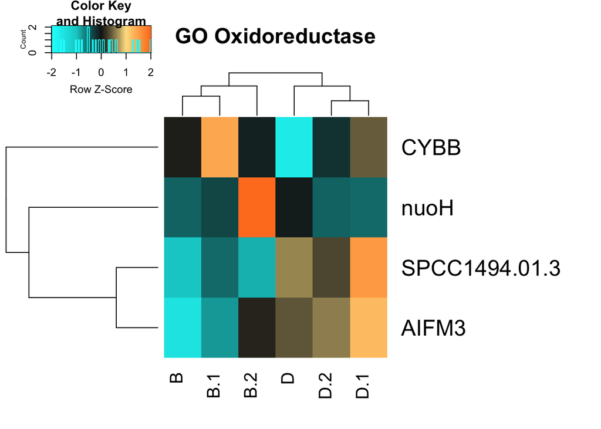

```r
heatmap_oxidoreductase_sig = heatmap.2(as.matrix(explc_oxr), col = col0, Rowv = TRUE, Colv = TRUE, scale = "row",
                                   dendrogram = "both",
                                   trace = "none",
                                   main = "GO Oxidoreductase",
                                   margin = c(5,15))
```

- For the final step, I’m going to make a heatmap of all the genes that are differentially regulated (alpha = 0.05 to account for the count differences) that will allow for further exploration

```r
BD_DE_05 = filter(BD_DE, pval.BD <= 0.05, preserve = TRUE)
head(BD_DE_05)
```

```
##           X         B       B.1        B.2          D       D.1        D.2
## 1 ofav12680 3.9013383 0.5344855 -0.2512211 -0.6238076 0.3815352 -0.2312006
## 2 ofav25617 3.1815954 1.9685145  0.1416015  0.2885600 0.5875111 -0.3165155
## 3 ofav27005 2.6723453 0.4876459  0.7755144 -0.9128296 0.3432648 -0.1800952
## 4 ofav11857 0.1229006 4.6368761  0.4413966 -0.2855968 0.4878168 -0.4706502
## 5 ofav45791 1.1906039 3.2534535  1.2123773 -1.6779025 0.3691897 -0.7821711
## 6 ofav55589 3.5222223 0.5311704  0.6921424 -1.0098290 0.3803662 -0.4522073
##       pval.BD   padj.BD
## 1 0.007493289        NA
## 2 0.024907553        NA
## 3 0.048623129        NA
## 4 0.001299003 0.1449606
## 5 0.001659914        NA
## 6 0.005612212        NA
```

```r
rlog_BD_05 = BD_DE_05[,1:7] %>%
  rename(Gene_id = X)
head(rlog_BD_05)
```

```
##     Gene_id         B       B.1        B.2          D       D.1        D.2
## 1 ofav12680 3.9013383 0.5344855 -0.2512211 -0.6238076 0.3815352 -0.2312006
## 2 ofav25617 3.1815954 1.9685145  0.1416015  0.2885600 0.5875111 -0.3165155
## 3 ofav27005 2.6723453 0.4876459  0.7755144 -0.9128296 0.3432648 -0.1800952
## 4 ofav11857 0.1229006 4.6368761  0.4413966 -0.2855968 0.4878168 -0.4706502
## 5 ofav45791 1.1906039 3.2534535  1.2123773 -1.6779025 0.3691897 -0.7821711
## 6 ofav55589 3.5222223 0.5311704  0.6921424 -1.0098290 0.3803662 -0.4522073
```

```r
sigDEG_BD = iso2go %>%
  left_join(rlog_BD_05) %>%
  left_join(gene) %>%
  mutate(gene_symbol = make.names(gene_symbol, unique = TRUE)) %>%
  column_to_rownames(var = "gene_symbol") %>%
  dplyr::select(-GO.terms, -Description, -Gene_id) %>%
  drop_na() %>%
  dplyr::select(sort(current_vars()))
head(sigDEG_BD)
```

```
##                   B      B.1        B.2         D       D.1        D.2
## STUB1     7.1563062 5.602483  4.8497200 5.0958477 4.7076618  4.4733256
## ublcp1    0.2121013 6.018121 -0.2186314 0.7238322 0.5848564 -1.2364413
## tax1bp1b  7.0970164 7.362182  6.6838437 6.0637200 6.1902805  6.0874923
## At3g01520 5.1704500 5.225843  6.3631045 6.8617835 7.3374493  7.2639473
## PRPF3     3.9768176 2.290392  1.0806443 1.0222547 0.9254704  0.2769417
## Sytl5     6.0177872 2.415606  5.0660043 3.7733065 3.1231801  4.0135688
```

```r
nrow(sigDEG_BD)
```

```
## [1] 213
```

- sigDEG_BD are all my significant DEGs between B and D in the right format with alpha of 0.05
- First making a heatmap of the raw values

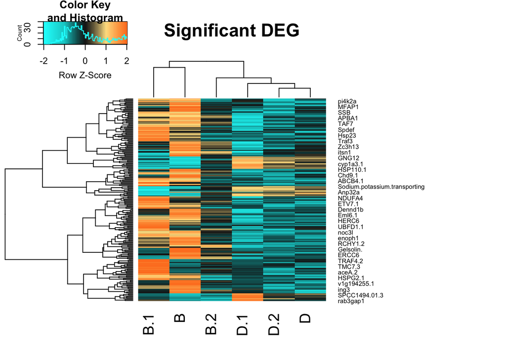

```r
heatmap_sigDEG = heatmap.2(as.matrix(sigDEG_BD), col = col0, Rowv = TRUE, Colv = TRUE, scale = "row",
                           dendrogram = "both",
                           trace = "none",
                           main = "Significant DEG",
                           margin = c(5,15))
```

- Now calculating the difference from the mean and making that a heatmap

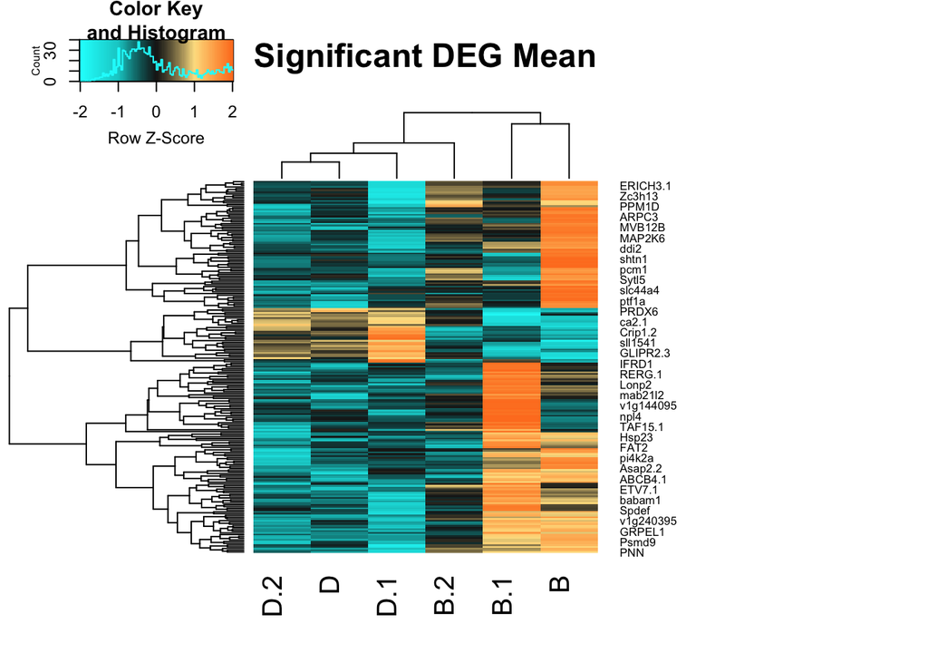

```r
sigDEG_BD_means = apply(sigDEG_BD, 1, mean)
explc_sig = sigDEG_BD-sigDEG_BD_means
heatmap_sigDEG_means = heatmap.2(as.matrix(explc_sig), col = col0, Rowv = TRUE, Colv = TRUE, scale = "row",
                           dendrogram = "both",
                           trace = "none",
                           main = "Significant DEG Mean",
                           margin = c(5,15))
```

- Make this list of genes and expression values into a csv file for future reference
- Also attach the jpg image of the heatmap so that all the gene symbols are visible

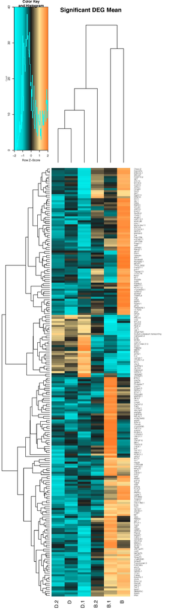

```r
write.csv(explc_sig, "0.5DEG_BD_genesymbols.csv", quote = F)
knitr::opts_chunk$set(echo = TRUE)
knitr::include_graphics("Ofav 0.5 Sig DEG Mean Heatmap.jpg")
```

- MAIN FINDINGS:
- From GO MWU analysis of ranked GO term enrichment, we found that Postitive Regulation of Cell Proliferation and various Oxidoreductase activities are enriched in samples hosting D compared to B recruits
- From analysis of all significantly differentially expressed genes, we identified the following:
- SODC (superoxide dismutase) is strongly upregulated in coral hosting D compared to B; SODC is an NF-kB response gene; this is consistent with our expectations that coral hosting D would perform better under thermal/oxidative stress because increased SOD means an increased ability to deal with oxidative stress
- To a lesser extent, HSP110 may be downregulated in D compared to B, but this may be an effect of count value
- TNFSF10 and TRAF4.2 were identified as upregulated in one B (B.1) compared to D (i.e., downregulated in D), but again, this may be an effect of count size